# Lab 1 Tutorial | PAF 516

Measurement, Indexing & Multi-Scale Mapping

**How to use this file**

**First time:** Click the **Render** button (or Cmd+Shift+K / Ctrl+Shift+K) to produce a complete HTML with all results. Then come back and run chunk by chunk to understand each step.

**Chunk by chunk:** Place cursor inside any chunk → Cmd+Return (Mac) / Ctrl+Enter (PC).

This file is for learning — do not edit it. When you are ready for the assignment, download `Lab1_Assignment.qmd` from the [Lab 1 Assignment page](https://antjam-howell.github.io/paf-516-labs/lab1-assignment.html).

```r
# ── One-time course environment setup ─────────────────────────────────────
if (!file.exists("~/.paf516_ready")) {
  if (!requireNamespace("renv", quietly = TRUE)) install.packages("renv")
  tmp <- tempfile(fileext = ".lock")
  download.file(
    url      = "https://raw.githubusercontent.com/AntJam-Howell/paf-516-labs/main/renv.lock",
    destfile = tmp, mode = "wb"
  )
  renv::restore(lockfile = tmp, prompt = FALSE)
  file.create("~/.paf516_ready")
}

library(tidyverse)
library(tidycensus)
library(sf)
library(tigris)
library(psych)
library(corrplot)
library(viridis)
library(ggplot2)
library(patchwork)
```

```r
# ── TROUBLESHOOTING: If packages fail to install ───────────────────────────
# If one or more packages fail to install, try the following steps in order.
#
# 1) Check your RStudio project and working directory (all users).
#    RStudio can default to an old or incorrect project folder, which causes
#    package installation to fail. Fix by creating a new RStudio project:
#      File → New Project → Existing Directory → navigate to your PAF516/Lab1/ folder
#    Then re-run the packages chunk and try rendering again.
#
# 2) Windows only — install Rtools.
#    Rtools provides the compiler needed to build some R packages from source.
#    Run these two lines in your RStudio Console:
#      install.packages("installr")
#      installr::install.Rtools()
#    Then restart RStudio and try rendering again.
```

# Step 0: Get a US Census API Key

Every lab in this course pulls data directly from the **US Census Bureau’s API** (Application Programming Interface). The Census API is a free public service that lets programs — including R packages like `tidycensus` — request specific tables, geographies, and years of data on demand, instead of downloading bulk files manually. Think of it as a direct pipeline between your R session and the Census Bureau’s data warehouse.

To use the API you need a **key** — a short text string that identifies you as an authorized user. The key is free, has no usage limits for our purposes, and only needs to be set up once. Without it, every `get_acs()` call in this course will fail.

**Setup (one time only):**

1. Go to https://api.census.gov/data/key_signup.html and request a key. You will receive it by email within a few minutes.
2. In your **RStudio Console** (not in this QMD), run the following line, replacing the placeholder with your actual key:

```r
census_api_key("YOUR_KEY_HERE", install = TRUE)
```

3. Restart R: **Session → Restart R**.

That’s it. The `install = TRUE` argument saves the key to a file called `.Renviron` in your home directory, so R will load it automatically every time you start a new session. You will not need to repeat this step in future labs.

# Step 1: Retrieve Census Variables

We build an **Economic Hardship Index** from 5 computed rates at the Arizona tract level. Each rate requires a numerator/denominator pair from the ACS, so the variable list contains 10 census codes — but they collapse into 5 measures: poverty rate, unemployment rate, no high school diploma rate, no health insurance rate, and median income.

```r
hardship_vars <- c(
  pov_below50    = "C17002_002",   # Income-to-poverty ratio under .50
  pov_50to99     = "C17002_003",   # Income-to-poverty ratio .50 to .99
  pov_den        = "C17002_001",   # Total population (poverty universe)
  median_income  = "B19013_001",   # Median household income
  pct_unemp_num  = "B23025_005",   # Unemployed population
  pct_unemp_den  = "B23025_002",   # In labor force
  pct_no_hs_num  = "B15003_002",   # Population with less than high school
  pct_no_hs_den  = "B15003_001",   # Total population 25+
  pct_no_ins_num = "B27010_017",   # Without health insurance (18–34)
  pct_no_ins_den = "B27010_001"    # Total population (insurance universe)
)

CenDF <- get_acs(
  geography    = "tract",
  variables    = hardship_vars,
  state        = "AZ",
  year         = 2023,
  survey       = "acs5",
  geometry     = TRUE,
  progress_bar = FALSE
)
```

**Variable justification:**

| Variable | Census Code | Why Included |
| --- | --- | --- |
| Poverty rate | C17002_002 + _003 / _001 | Direct measure of economic deprivation |
| Unemployment rate | B23025_005 / B23025_002 | Labor market hardship |
| No high school diploma | B15003_002 / B15003_001 | Education predicts economic outcomes |
| No health insurance | B27010_017 / B27010_001 | Reflects economic vulnerability |
| Median household income | B19013_001 | Core income measure (reverse coded) |

# Step 2: Compute Rates and Standardize

Reshape from long to wide, compute percentage variables, and standardize to z-scores.

```r
CenDF_wide <- CenDF %>%
  select(-moe) %>%
  pivot_wider(names_from = variable, values_from = estimate)

CenDF_wide <- CenDF_wide %>%
  mutate(
    poverty_rate = (pov_below50 + pov_50to99) / pov_den,
    unemp_rate   = pct_unemp_num / pct_unemp_den,
    no_hs_rate   = pct_no_hs_num / pct_no_hs_den,
    no_ins_rate  = pct_no_ins_num / pct_no_ins_den
  )

# Select indicator variables and standardize
index_vars <- CenDF_wide %>%
  st_drop_geometry() %>%
  select(poverty_rate, unemp_rate, no_hs_rate, no_ins_rate, median_income) %>%
  drop_na()

index_z <- index_vars %>%
  mutate(across(everything(), ~ as.numeric(scale(.)))) %>%
  mutate(median_income = -1 * median_income)  # reverse-code: high income = low hardship
```

# Step 3: Cronbach’s Alpha

Assess whether the 5 items reliably measure the same underlying construct.

```r
alpha_result <- psych::alpha(index_z)
print(alpha_result)
```

```
Reliability analysis
Call: psych::alpha(x = index_z)

  raw_alpha std.alpha G6(smc) average_r S/N   ase    mean   sd median_r
      0.71      0.71     0.7      0.33 2.5 0.011 5.7e-16 0.68     0.31

    95% confidence boundaries
         lower alpha upper
Feldt     0.69  0.71  0.73
Duhachek  0.69  0.71  0.73

 Reliability if an item is dropped:
              raw_alpha std.alpha G6(smc) average_r S/N alpha se  var.r med.r
poverty_rate       0.58      0.58    0.51      0.25 1.4    0.017 0.0055  0.25
unemp_rate         0.69      0.69    0.66      0.35 2.2    0.012 0.0235  0.31
no_hs_rate         0.70      0.70    0.67      0.37 2.3    0.012 0.0296  0.35
no_ins_rate        0.71      0.71    0.69      0.39 2.5    0.011 0.0254  0.36
median_income      0.62      0.62    0.58      0.29 1.7    0.015 0.0116  0.30

 Item statistics
                 n raw.r std.r r.cor r.drop     mean sd
poverty_rate  1725  0.82  0.82  0.81   0.67  7.9e-16  1
unemp_rate    1725  0.64  0.64  0.49   0.41  2.0e-15  1
no_hs_rate    1725  0.62  0.62  0.44   0.38 -5.4e-16  1
no_ins_rate   1725  0.59  0.59  0.40   0.34  1.4e-16  1
median_income 1725  0.75  0.75  0.70   0.56 -4.6e-17  1
```

```r
alpha_value <- alpha_result$total$raw_alpha
cat("Cronbach's alpha:", round(alpha_value, 3), "\n")
```

```
Cronbach's alpha: 0.712
```

**Interpreting the output:** The `raw_alpha` is our Cronbach’s alpha. The “Reliability if an item is dropped” section shows what alpha would be without each variable — if dropping an item increases alpha, it may not fit the construct well.

# Step 4: Build the Index and Visualize

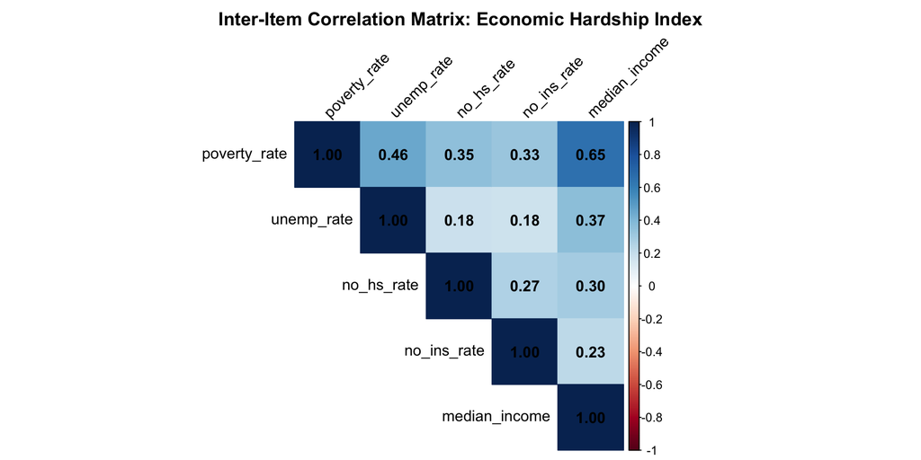

```r
cor_matrix <- cor(index_z, use = "complete.obs")

corrplot(
  cor_matrix,
  method      = "color",
  type        = "upper",
  addCoef.col = "black",
  tl.col      = "black",
  tl.srt      = 45,
  title       = "Inter-Item Correlation Matrix: Economic Hardship Index",
  mar         = c(0, 0, 2, 0)
)
```

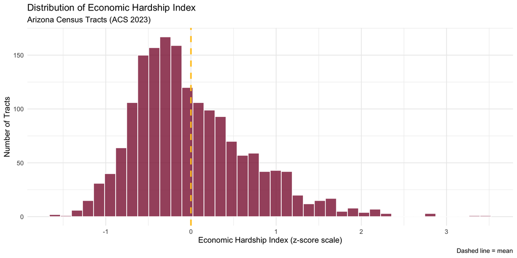

```r
index_z$hardship_index <- rowMeans(index_z, na.rm = TRUE)

ggplot(index_z, aes(x = hardship_index)) +
  geom_histogram(bins = 40, fill = "#8c1d40", color = "white", alpha = 0.8) +
  geom_vline(xintercept = mean(index_z$hardship_index, na.rm = TRUE),
             linetype = "dashed", color = "#ffc627", linewidth = 1) +
  theme_minimal() +
  labs(
    title    = "Distribution of Economic Hardship Index",
    subtitle = "Arizona Census Tracts (ACS 2023)",
    x        = "Economic Hardship Index (z-score scale)",
    y        = "Number of Tracts",
    caption  = "Dashed line = mean"
  )
```

```r
CenDF_complete <- CenDF_wide %>%
  drop_na(poverty_rate, unemp_rate, no_hs_rate, no_ins_rate, median_income)
CenDF_complete$hardship_index <- index_z$hardship_index
```

# Step 5: National County-Level Map

Pull the same 5 variables at the **county level** for the entire US and map national hardship patterns.

```r
county_df <- get_acs(
  geography    = "county",
  variables    = hardship_vars,
  year         = 2023,
  survey       = "acs5",
  geometry     = TRUE,
  progress_bar = FALSE
)
```

```r
county_wide <- county_df %>%
  select(-moe) %>%
  pivot_wider(names_from = variable, values_from = estimate) %>%
  mutate(
    poverty_rate = (pov_below50 + pov_50to99) / pov_den,
    unemp_rate   = pct_unemp_num / pct_unemp_den,
    no_hs_rate   = pct_no_hs_num / pct_no_hs_den,
    no_ins_rate  = pct_no_ins_num / pct_no_ins_den
  )

county_index <- county_wide %>%
  st_drop_geometry() %>%
  select(poverty_rate, unemp_rate, no_hs_rate, no_ins_rate, median_income) %>%
  drop_na() %>%
  mutate(across(everything(), ~ as.numeric(scale(.)))) %>%
  mutate(median_income = -1 * median_income)

county_index$hardship_index <- rowMeans(county_index, na.rm = TRUE)

county_complete <- county_wide %>%
  drop_na(poverty_rate, unemp_rate, no_hs_rate, no_ins_rate, median_income)
county_complete$hardship_index <- county_index$hardship_index
```

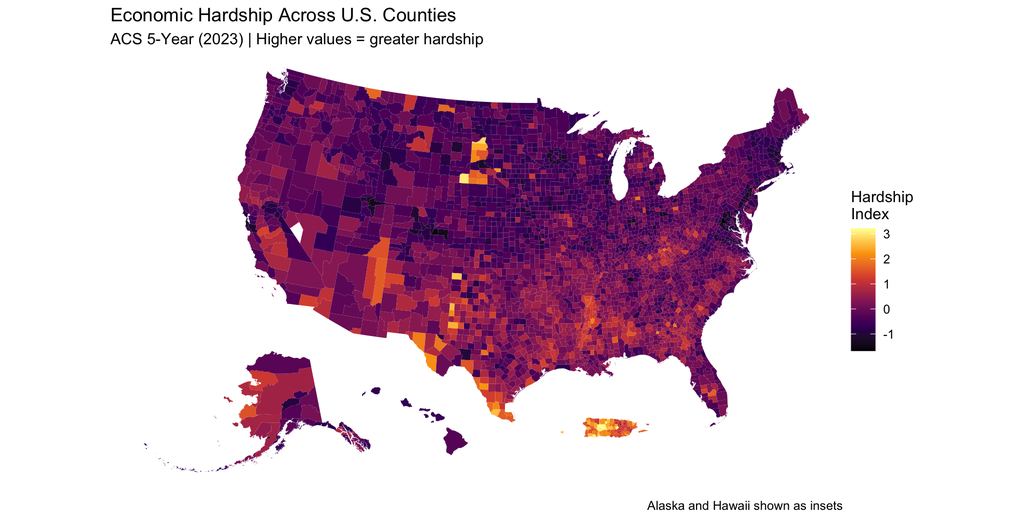

```r
county_shifted <- shift_geometry(county_complete)

ggplot(county_shifted) +
  geom_sf(aes(fill = hardship_index), color = NA, linewidth = 0) +
  scale_fill_viridis_c(option = "inferno", name = "Hardship\nIndex", na.value = "grey80") +
  theme_void() +
  labs(
    title    = "Economic Hardship Across U.S. Counties",
    subtitle = "ACS 5-Year (2023) | Higher values = greater hardship",
    caption  = "Alaska and Hawaii shown as insets"
  )
```

# Step 6: Arizona Census Tract Map

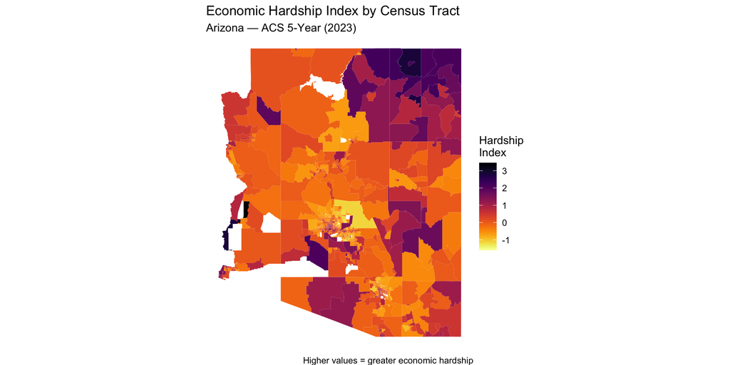

```r
ggplot(CenDF_complete) +
  geom_sf(aes(fill = hardship_index), color = NA) +
  scale_fill_viridis(option = "inferno", direction = -1, name = "Hardship\nIndex") +
  theme_void() +
  labs(
    title    = "Economic Hardship Index by Census Tract",
    subtitle = "Arizona — ACS 5-Year (2023)",
    caption  = "Higher values = greater economic hardship"
  )
```

# Step 7: Maricopa County Block Group Map

Block groups are the smallest ACS geography, revealing fine-grained variation within tracts.

```r
cbg_df <- get_acs(
  geography    = "block group",
  variables    = hardship_vars,
  state        = "AZ",
  county       = "Maricopa",
  year         = 2023,
  survey       = "acs5",
  geometry     = TRUE,
  progress_bar = FALSE
)
```

```r
cbg_wide <- cbg_df %>%
  select(-moe) %>%
  pivot_wider(names_from = variable, values_from = estimate) %>%
  mutate(
    poverty_rate = (pov_below50 + pov_50to99) / pov_den,
    unemp_rate   = pct_unemp_num / pct_unemp_den,
    no_hs_rate   = pct_no_hs_num / pct_no_hs_den,
    no_ins_rate  = pct_no_ins_num / pct_no_ins_den
  )

cbg_index <- cbg_wide %>%
  st_drop_geometry() %>%
  select(poverty_rate, unemp_rate, no_hs_rate, no_ins_rate, median_income) %>%
  drop_na() %>%
  mutate(across(everything(), ~ as.numeric(scale(.)))) %>%
  mutate(median_income = -1 * median_income)

cbg_index$hardship_index <- rowMeans(cbg_index, na.rm = TRUE)

cbg_complete <- cbg_wide %>%
  drop_na(poverty_rate, unemp_rate, no_hs_rate, no_ins_rate, median_income)
cbg_complete$hardship_index <- cbg_index$hardship_index
```

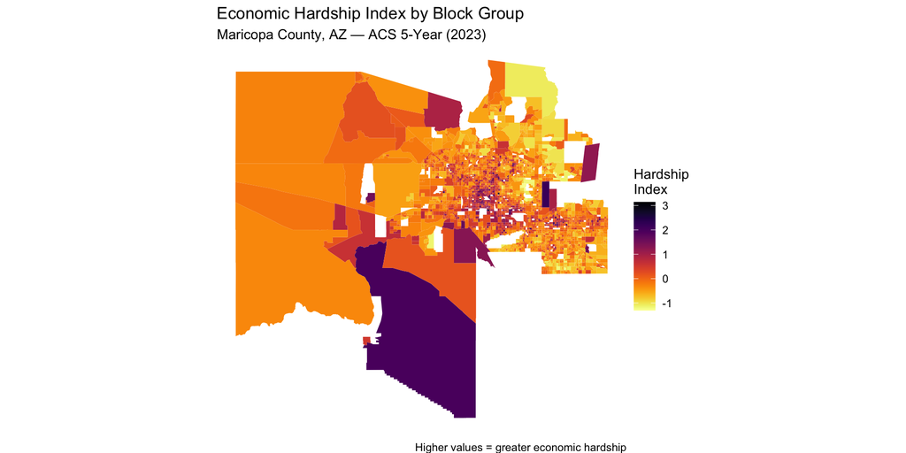

```r
ggplot(cbg_complete) +
  geom_sf(aes(fill = hardship_index), color = NA) +
  scale_fill_viridis(option = "inferno", direction = -1, name = "Hardship\nIndex") +
  theme_void() +
  labs(
    title    = "Economic Hardship Index by Block Group",
    subtitle = "Maricopa County, AZ — ACS 5-Year (2023)",
    caption  = "Higher values = greater economic hardship"
  )
```

# Step 8: Enriched Index — Does Measurement Choice Change the Map?

The 5-variable baseline captures five well-established dimensions of economic hardship. But hardship is multi-dimensional. A broader index might also reflect:

| New Variable | Dimension | Census Code |
| --- | --- | --- |
| Renter-occupied rate | Housing instability / wealth exclusion | B25003_003 / B25003_001 |
| No vehicle access | Transportation barrier | B08201_002 / B08201_001 |
| Single-parent household rate | Family structure stress | B11012_010 / B11001_001 |
| Public assistance income rate | Direct economic need | B19057_002 / B19057_001 |
| No internet access rate | Digital divide / economic barrier | B28002_013 / B28002_001 |

Adding these five produces a **10-variable enriched index**. The key question: does this broader measurement change which communities we identify as hardship hotspots — and how much?

```r
hardship_vars_10 <- c(
  # ── Original 5 variable pairs ──────────────────────────────────────
  pov_below50    = "C17002_002",   pov_50to99     = "C17002_003",
  pov_den        = "C17002_001",   median_income  = "B19013_001",
  pct_unemp_num  = "B23025_005",   pct_unemp_den  = "B23025_002",
  pct_no_hs_num  = "B15003_002",   pct_no_hs_den  = "B15003_001",
  pct_no_ins_num = "B27010_017",   pct_no_ins_den = "B27010_001",
  # ── 5 new dimensions ───────────────────────────────────────────────
  renter_num     = "B25003_003",   renter_den     = "B25003_001",
  noveh_num      = "B08201_002",   noveh_den      = "B08201_001",
  sinpar_num     = "B11012_010",   sinpar_den     = "B11001_001",
  pubast_num     = "B19057_002",   pubast_den     = "B19057_001",
  noinet_num     = "B28002_013",   noinet_den     = "B28002_001"
)

CenDF_10 <- get_acs(
  geography    = "tract",
  variables    = hardship_vars_10,
  state        = "AZ",
  year         = 2023,
  survey       = "acs5",
  geometry     = TRUE,
  progress_bar = FALSE
)
```

```r
CenDF_wide_10 <- CenDF_10 %>%
  select(-moe) %>%
  pivot_wider(names_from = variable, values_from = estimate) %>%
  mutate(
    # Original 5
    poverty_rate = (pov_below50 + pov_50to99) / pov_den,
    unemp_rate   = pct_unemp_num  / pct_unemp_den,
    no_hs_rate   = pct_no_hs_num  / pct_no_hs_den,
    no_ins_rate  = pct_no_ins_num / pct_no_ins_den,
    # New 5
    renter_rate  = renter_num / renter_den,
    noveh_rate   = noveh_num  / noveh_den,
    sinpar_rate  = sinpar_num / sinpar_den,
    pubast_rate  = pubast_num / pubast_den,
    noinet_rate  = noinet_num / noinet_den
  )

CenDF_complete_10 <- CenDF_wide_10 %>%
  drop_na(poverty_rate, unemp_rate, no_hs_rate, no_ins_rate,
          median_income, renter_rate, noveh_rate,
          sinpar_rate, pubast_rate, noinet_rate)

index_z_10 <- CenDF_complete_10 %>%
  st_drop_geometry() %>%
  select(poverty_rate, unemp_rate, no_hs_rate, no_ins_rate,
         median_income, renter_rate, noveh_rate,
         sinpar_rate, pubast_rate, noinet_rate) %>%
  mutate(across(everything(), ~ as.numeric(scale(.)))) %>%
  mutate(median_income = -1 * median_income)   # reverse-code

# Compare alpha: 5-variable vs 10-variable
alpha_5  <- psych::alpha(index_z  |> select(-hardship_index))
alpha_10 <- psych::alpha(index_z_10)

cat("5-variable alpha: ", round(alpha_5$total$raw_alpha,  3), "\n")
```

```
5-variable alpha:  0.712
```

```r
cat("10-variable alpha:", round(alpha_10$total$raw_alpha, 3), "\n")
```

```
10-variable alpha: 0.816
```

```r
cat("Change:           ", round(alpha_10$total$raw_alpha - alpha_5$total$raw_alpha, 3), "\n")
```

```
Change:            0.104
```

```r
# Build enriched index
index_z_10$hardship_index_10 <- rowMeans(index_z_10, na.rm = TRUE)
CenDF_complete_10$hardship_index_10 <- index_z_10$hardship_index_10
```

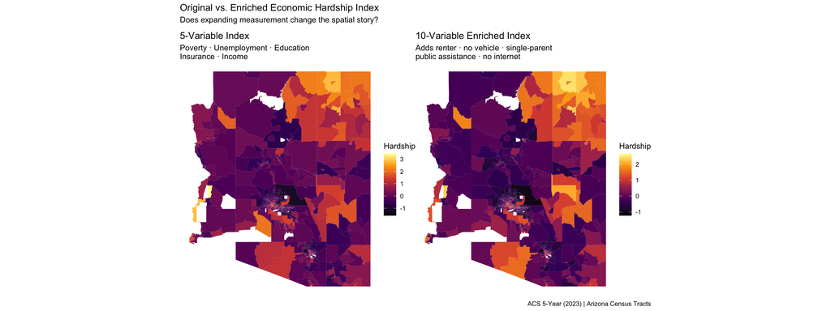

```r
p_5var <- ggplot(CenDF_complete) +
  geom_sf(aes(fill = hardship_index), color = NA) +
  scale_fill_viridis_c(option = "inferno", name = "Hardship",
                       na.value = "grey80") +
  theme_void() +
  labs(title = "5-Variable Index",
       subtitle = "Poverty · Unemployment · Education\nInsurance · Income")

p_10var <- ggplot(CenDF_complete_10) +
  geom_sf(aes(fill = hardship_index_10), color = NA) +
  scale_fill_viridis_c(option = "inferno", name = "Hardship",
                       na.value = "grey80") +
  theme_void() +
  labs(title = "10-Variable Enriched Index",
       subtitle = "Adds renter · no vehicle · single-parent\npublic assistance · no internet")

p_5var + p_10var +
  plot_annotation(
    title    = "Original vs. Enriched Economic Hardship Index",
    subtitle = "Does expanding measurement change the spatial story?",
    caption  = "ACS 5-Year (2023) | Arizona Census Tracts"
  )
```

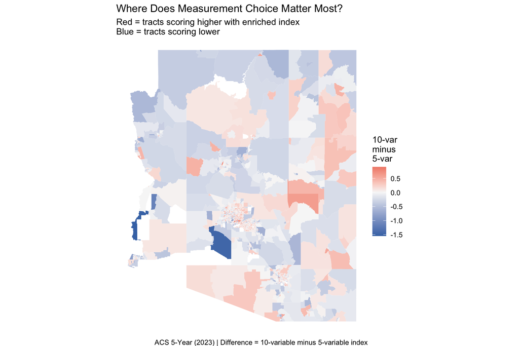

```r
compare_df <- CenDF_complete_10 %>%
  select(GEOID, geometry, hardship_index_10) %>%
  left_join(
    CenDF_complete %>% st_drop_geometry() %>% select(GEOID, hardship_index),
    by = "GEOID"
  ) %>%
  mutate(diff_10_minus_5 = hardship_index_10 - hardship_index)

ggplot(compare_df) +
  geom_sf(aes(fill = diff_10_minus_5), color = NA) +
  scale_fill_gradient2(
    low = "#4575b4", mid = "#f7f7f7", high = "#d73027",
    midpoint = 0, name = "10-var\nminus\n5-var"
  ) +
  theme_void() +
  labs(
    title    = "Where Does Measurement Choice Matter Most?",
    subtitle = "Red = tracts scoring higher with enriched index\nBlue = tracts scoring lower",
    caption  = "ACS 5-Year (2023) | Difference = 10-variable minus 5-variable index"
  )
```

**Interpreting the difference map:** Red tracts are communities where the enriched index reveals *more hardship* than the baseline captured — likely places with high renter rates, low vehicle access, or many single-parent households that census income and poverty measures undercount. Blue tracts are places where those new dimensions don’t add to the hardship signal — often wealthier suburbs where some of those variables don’t apply.

**Ready for the assignment?**

Head to the [Lab 1 Assignment page](https://antjam-howell.github.io/paf-516-labs/lab1-assignment.html) to download `Lab1_Assignment.qmd`. The assignment asks you to add **SNAP receipt** as an 11th variable and show whether one more dimension still meaningfully shifts the difference map.